# Time Warp Profile Phase Averaging

*Rahul Singh, 15 July 2023*

Sioros, G., & Nymoen, K. (2021, September 2). Accurate shape and phase averaging of time series through Dynamic Time Warping. arXiv.org. https://arxiv.org/abs/2109.00978v1

A few notes:

- NumPy is the only hard dependency. The inclusion of `matplotlib.pyplot` is purely for plotting purposes, of which there is only a single function doing very basic plotting. `random`, `itertools.combinations`, `datetime` and `time` are modules contained within Python's standard library, so these do not count as dependencies.
- It's recommended to have time sequences of >= 5 elements at the minimum. Very large sets of sequences (around 1000 sequences and/or >~ 1550-element arrays) will of course take very long to complete (although the algorithm does indeed converge).
- Equal length sequences sent into the averaging function might not yield an appropriate response signal (it might be shifted in phase, or it might line up perfectly). Gathering a guess, this might be due to the nature of the averaging function which samples points twice when compared to the arithmetic mean.

The docstrings for each function, coupled with referring to the research paper (specifically sections 3 and 4) provide all the narration required for this notebook.

```python
# general imports
import matplotlib.pyplot as plt
import numpy as np
import random
import time

# specific imports
from datetime import datetime
from itertools import combinations
```

## Single average

```python
p1 = np.array([1, 2, 4, 9, 6, 5, 6, 9])
p2 = np.array([14, 12, 9, 8, 9, 8, 12])
```

```python
def dtw_cost_matrix(seq_1, seq_2, distance = np.linalg.norm):
    """
    Dynamic Time Warping function that returns the cumulative cost matrix given
    two time sequences, `seq_1` and `seq_2`. The sequences are expected to be
    numpy arrays.

    This function seeds a matrix of `seq_1` rows and `seq_2` columns with np.inf
    and sets coordinate (0, 0) to 0, in order to organise the eventual warping
    path in an easier fashion. After initialisation, each cell is filled with
    the values as the sum of two components: the Euclidean distances between
    each element of both series, and the minimum value of the 3 adjacent,
    preceeding elements.

    Parameters:
    `seq_1`: np.array
        A 1D time sequence (a vector) to average with. There should not be any
        datetime column, just a sequence of values.

    `seq_2`: np.array
        A 1D time sequence (a vector) to average with. There should not be any
        datetime column, just a sequence of values.

    Returns a numpy matrix shaped N x M, where N is the length of `seq_1` and
    M is the length of `seq_2`.

    Example:
    >>> p1 = np.array([1, 2, 4, 9, 6, 5, 6, 9])
    >>> p2 = np.array([14, 12, 9, 8, 9, 8, 12])
    >>> dtw_cost_matrix(p1, p2)
    matrix([[ 0., inf, inf, inf, inf, inf, inf],
            [inf, 10., 17., 23., 30., 36., 46.],
            [inf, 18., 15., 19., 24., 28., 36.],
            [inf, 21., 15., 16., 16., 17., 20.],
            [inf, 27., 18., 17., 19., 18., 23.],
            [inf, 34., 22., 20., 21., 21., 25.],
            [inf, 40., 25., 22., 23., 23., 27.],
            [inf, 43., 25., 23., 22., 23., 26.]])
    """
    # locally-scoped variables
    py_len = len
    py_min = min
    py_range = range
    fn_dist = distance

    # functionality
    dtw_matrix = np.matrix(np.ones((py_len(seq_1), py_len(seq_2))) * np.inf)
    dtw_matrix[0, 0] = 0.0

    for i in py_range(1, py_len(seq_1)):
        for j in py_range(1, py_len(seq_2)):
            cost = distance(seq_1[i] - seq_2[j])
            dtw_matrix[i, j] = cost + py_min(
                dtw_matrix[i-1, j],
                dtw_matrix[i, j-1],
                dtw_matrix[i-1, j-1]
            )

    return dtw_matrix


mat = dtw_cost_matrix(
    np.array([1, 2, 4, 9, 6, 5, 6, 9]),
    np.array([14, 12, 9, 8, 9, 8, 12])
)
mat
```

```
matrix([[ 0., inf, inf, inf, inf, inf, inf],
        [inf, 10., 17., 23., 30., 36., 46.],
        [inf, 18., 15., 19., 24., 28., 36.],
        [inf, 21., 15., 16., 16., 17., 20.],
        [inf, 27., 18., 17., 19., 18., 23.],
        [inf, 34., 22., 20., 21., 21., 25.],
        [inf, 40., 25., 22., 23., 23., 27.],
        [inf, 43., 25., 23., 22., 23., 26.]])
```

```python
def dtw_opt_path(cost_matrix):
    """
    Function to chart the optimal warping path through a provided DTW matrix,
    `mat`. Starting from the end of the matrix, i.e. from position (N, M), it
    traverses the matrix backwards looking for the minimum value between
    elements adjacent to the current one in forward-step. E.g. for the matrix:
    1 | 2 | 3
    --+---+--
    4 | 5 | 4
    --+---+--
    3 | 2 | 1

    It begins from position (n, m) with the first value being 1. The second
    value is the minimum of (4, 5, 2) = 2. The third value is the minimum of
    (5, 4, 3) = 3. The fourth value is the minimum of (5, 4) = 4, and the final
    value is the minumum of (5, 2, 1) = 1. The path is therefore
    [(3, 3), (3, 2), (3, 1), (2, 1), (1, 1)].

    Parameters:
    `cost_matrix`: np.matrix
        A DTW cost matrix between two time sequences shaped N x M.

    Returns a list of tuples, where each tuple contains the indices of the
    optimal path to take through `cost_matrix`.

    Example:
    >>> mat = dtw_cost_matrix(p1, p2)
    >>> dtw_opt_path(mat)
    [(0, 0), (1, 1), (2, 2), (3, 3), (3, 4), (4, 5), (5, 5), (6, 5), (7, 6)]
    """
    # locally-scoped variables
    matches = []
    m_append = matches.append
    np_argmin = np.argmin

    # functionality
    (i, j) = cost_matrix.shape
    i -= 1
    j -= 1

    while i > 0 or j > 0:
        m_append((i, j))
        mov = np_argmin([
            cost_matrix[i - 1, j],      # move one row up
            cost_matrix[i - 1, j - 1],  # move diagonally
            cost_matrix[i, j - 1]       # move one col left
        ])

        match mov:
            case 0:
                i -= 1
            case 1:
                i -= 1
                j -= 1
            case 2:
                j -= 1

    m_append((0, 0))
    matches.reverse()
    return matches


path = dtw_opt_path(mat)
path
```

```
[(0, 0), (1, 1), (2, 2), (3, 3), (3, 4), (4, 5), (5, 5), (6, 5), (7, 6)]
```

```python
def warp_profile(dtw_path):
    """
    Function that calculates the warp profile between two time sequences given
    their optimal DTW path. The DTW path will be in terms of (t1, t2) coordinate
    tuples representing the points that ought to be aligned; the TWP path will
    be in terms of (tau, phi) which represents phase difference over time.

    Parameters:
    `dtw_path`: iterable of tuples
        The optimal DTW path. ANy iterable will work, the only constraint is the
        iterable ought to contain tuples of indices.

    Returns a dictionary containg tau: phi key-value pairs, where tau is the
    time index and phi is the phase difference between both time sequences.

    Example:
    >>> path = dtw_opt_path(mat)
    >>> warp_profile(path)
    {0: 0,
     1: 0,
     2: 0,
     3: 0,
     4: 0,
     5: 0,
     6: 0,
     7: 1,
     8: 1,
     9: 1,
     10: 0,
     11: -1,
     12: -1,
     13: -1}
    """
    # locally-scoped variables
    py_len = len
    np_arr = np.array

    # functionality
    diff_path = [
        np_arr(dtw_path[i + 1]) - np_arr(dtw_path[i])
        for i in range(py_len(dtw_path) - 1)
    ]

    phi = {0: 0}
    t = 0

    for d in diff_path:  # DO NOT ENUMERATE dif WITH {t, d in enum(dif)}!!!
        match np.diff(d):
            case 0:
                phi[t + 1] = phi[t + 2] = phi[t]
                t += 2
            case -1:
                phi[t + 1] = phi[t] - 1
                t += 1
            case 1:
                phi[t + 1] = phi[t] + 1
                t += 1

    return phi


wprof = warp_profile(path)
wprof
```

```
{0: 0,
 1: 0,
 2: 0,
 3: 0,
 4: 0,
 5: 0,
 6: 0,
 7: 1,
 8: 1,
 9: 1,
 10: 0,
 11: -1,
 12: -1,
 13: -1}
```

```python
def inspect_path(path, cost_mat):
    """
    Function that helps in charting out what the optimal path looks like within
    the context of the corresponding cost matrix. Usually used for verification
    and/or introspection.

    Parameters:
    `path`: iterable of tuples.
        The optimal path through the DTW cost matrix. Any iterable will do as
        long as the tuples of indices are valid coordinates in `cost_mat`.

    `cost_mat`: np.matrix
        The DTW cost matrix for the corresponding sequences under analysis.

    Returns nothing, prints the corresponding cost for each tuple of indices in
    `path`.

    Example:
    >>> inspect_path(path, mat)
    matrix(0, 0)	-> 0.0
    matrix(1, 1)	-> 10.0
    matrix(2, 2)	-> 15.0
    matrix(3, 3)	-> 16.0
    matrix(3, 4)	-> 16.0
    matrix(4, 5)	-> 18.0
    matrix(5, 5)	-> 21.0
    matrix(6, 5)	-> 23.0
    matrix(7, 6)	-> 26.0
    """
    for p in path:
        print(f"matrix({p[0]}, {p[1]})\t-> {cost_mat[p[0], p[1]]}")


inspect_path(path, mat)
```

```
matrix(0, 0)	-> 0.0
matrix(1, 1)	-> 10.0
matrix(2, 2)	-> 15.0
matrix(3, 3)	-> 16.0
matrix(3, 4)	-> 16.0
matrix(4, 5)	-> 18.0
matrix(5, 5)	-> 21.0
matrix(6, 5)	-> 23.0
matrix(7, 6)	-> 26.0
```

```python
def twp_phase_distance(warp_profile):
    """
    Function that calculates the Euclidean phase distance (the 2-norm) between
    two time sequences, given their warp profile.

    Parameters:
    `warp_profile`: dictionary
        The warp profile dictionary, where keys are Tau (time indices) and
        values are Phi (phase alignment).

    Returns a scalar value.

    Example:
    >>> wprof = warp_profile(path)
    >>> twp_phase_distance(wprof)
    2.449489742783178
    """
    return np.linalg.norm(list(warp_profile.values()))


twp_phase_distance(wprof)
```

```
2.449489742783178
```

```python
def twp_average(seq_1, seq_2, warp_profile):
    """
    Function that computes the time warp profile's phase average between two
    given time sequences. The TWP's {Tau: Phi} coordinates maintain phase
    alignment between the sequences; these are used to find the phase-aligned
    arithmetic mean between corresponding elements of the two sequences.

    Parameters:
    `seq_1`: np.array
        A 1D time sequence (a vector) to average with. There should not be any
        datetime column, just a sequence of values.

    `seq_2`: np.array
        A 1D time sequence (a vector) to average with. There should not be any
        datetime column, just a sequence of values.

    `warp_profile`: dictionary
        The warp profile dictionary, where keys are Tau (time indices) and
        values are Phi (phase alignment).

    Returns a numpy nd-array sized `np.ceil((L_1 + L_2 - 1) / 2)`, where L_1 and
    L_2 are the lengths of `seq_1`, and `seq_2`.

    Example:
    >>> twp_average(p1, p2, wprof)
    array([7.5, 7. , 6.5, 8.5, 9. , 6.5, 7. ])
    """
    # locally-scoped variables
    py_int = int
    np_floor = np.floor
    wp_half = list(warp_profile.items())[::2]

    # functionality
    s1_i = np_floor([(t - p) / 2 for t, p in wp_half])
    s2_i = np_floor([(t + p) / 2 for t, p in wp_half])

    s1_tau = [seq_1[py_int(i)] for i in s1_i]
    s2_tau = [seq_2[py_int(i)] for i in s2_i]

    return np.mean([s1_tau, s2_tau], axis = 0)


twp_average(p1, p2, wprof)
```

```
array([7.5, 7. , 6.5, 8.5, 9. , 6.5, 7. ])
```

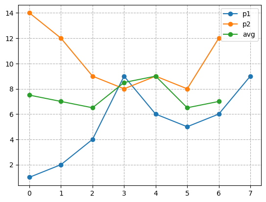

```python
plt.plot(p1, marker = 'o', label = "p1")
plt.plot(p2, marker = 'o', label = "p2")
plt.plot(twp_average(p1, p2, wprof), marker = 'o', label = "avg")
plt.grid(True, linestyle = "--")
plt.legend();
```

# Multi average

```python
p3 = np.array([7, 10, 9, 8, 11, 12])
l_p = {
    "p1": p1,
    "p2": p2,
    "p3": p3
}

l_p
```

```
{'p1': array([1, 2, 4, 9, 6, 5, 6, 9]),
 'p2': array([14, 12,  9,  8,  9,  8, 12]),
 'p3': array([ 7, 10,  9,  8, 11, 12])}
```

```python
def unequal_euc(*seqs):
    """
    Slight modification to the existing Euclidean distance function that allows
    for unequal length sequences, as described in equation 11.

    Parameters:
    `seqs`: iterable of np.array
        A collection of time sequences to compute distances between. Any kind of
        iterable will suffice, as long the time sequences are NumPy arrays.
        There should not be any datetime column, just a sequence of values.

    Returns a scalar value (the squared Euclidean distance).

    Example:
    >>> unequal_euc(p1, p2)
    matrix([[  0.        , 357.71428571],
            [  0.        ,   0.        ]])

    >>> p3 = np.array([7, 10, 9, 8, 11, 12])
    >>> unequal_euc(p1, p2, p3)
    matrix([[  0.        , 347.42857143, 201.33333333],
            [  0.        ,   0.        ,  66.5       ],
            [  0.        ,   0.        ,   0.        ]])
    """
    # locally-scoped variables
    py_len = len
    py_range = range
    np_sum = np.sum

    n = py_len(seqs)
    d_mat = np.matrix(np.zeros((n, n)))
    combos = list(combinations(range(n), 2))
    min_len = min([py_len(v) for v in seqs]) - 1

    # functionality
    for i, j in combos:
        s_1 = seqs[i]
        s_1_len = py_len(s_1)
        s_2 = seqs[j]
        s_2_len = py_len(s_2)

        arr = [(s_1[i] - s_2[i]) ** 2 for i in py_range(min_len)]
        d_mat[i, j] = (s_1_len / s_2_len) * np_sum(arr)

    return d_mat


# unequal_euc(p1, p2, p3)
```

````python
def twp_multi_average(seq_list, thresh = 0):
    """
    The iterative algorithm that finds the barycentric phase average of all
    provided time_sequences, in `aligned_t_arr`. The algorithm, as specified,
    is as follows:
    ```
    while max(dist) > thresh {
        1. compute the distance matrix of all time series received
        2. select the pair of sequences where dist(p, q) = max(dist)
        3. compute the phase array (TWP between p, q)
        4. compute the phase average between (p, q)
        5. replace (p, q) in the original matrix with their average
        6. recompute the distance matrix
    }
    7. compute the element-wise average between all replaced sequences
    F. return the barycentric phase average computed in step 7.
    ```

    Returns a numpy array containing the barycentric average of all time series
    that were sent in. Note: given in an n-dimensional heterogeneous matrix of
    multiple time sequences (each of which can be sized differently), only a
    vector will be returned.

    Example:
    >>> twp_multi_average([p1, p2])
    array([7.5, 7. , 6.5, 8.5, 9. , 6.5, 7. ])

    >>> twp_multi_average([p1, p2, p3])
    array([7.33333333, 8.        , 7.33333333, 8.33333333, 8.5       ,
           8.        ])
    """
    # locally-scoped variables
    np_unrav = np.unravel_index
    np_argmax = np.argmax
    np_arr = np.array

    get_euc = unequal_euc
    get_mat = dtw_cost_matrix
    get_pat = dtw_opt_path
    get_prf = warp_profile
    get_avg = twp_average

    # functionality
    d_mat = get_euc(*seq_list)

    while d_mat.max() > thresh:
        i, j = np_unrav(np_argmax(d_mat), d_mat.shape)
        s1 = seq_list[i]
        s2 = seq_list[j]

        # order of operations:
        # dtw_cost_matrix -> pathway -> warp_profile -> twp_average
        avg = get_avg(
            s1,
            s2,
            get_prf(
                get_pat(
                    get_mat(s1, s2)
                )
            )
        )

        seq_list[i] = seq_list[j] = avg
        d_mat = get_euc(*seq_list)

    return np.mean(seq_list, axis = 0)


twp_multi_average([p1, p2, p3])
````

```
array([7.33333333, 8.        , 7.33333333, 8.33333333, 8.5       ,
       8.        ])
```

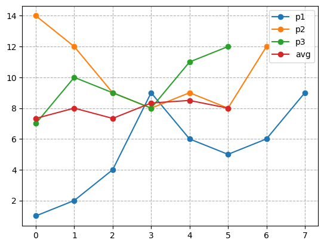

```python
def plot_averages(seq_list, marker_list = None, label_list = None):
    """
    Tiny function that plots out any given original sequences along with their
    TWP phase average for comparison.

    Parameters:
    `seq_list`: iterable of time sequences
        A collection of time sequences to compute distances between. Any kind of
        iterable will suffice, as long as there is no datetime column, just the
        sequence of values.

    `marker_list`: iterable of characters
        A collection of valid matplotlib marker styles to use for the plot, if
        desired. Refer to the matplotlib documentation for valid characters.

    `label_list`: iterable of strings
        A collection of strings to use for each sequence's plot as its label.
        These labels show up in the plot's legend.

    Returns nothing, plots internally.

    Example:
    >>> plot_averages(
            seq_list = [p1, p1, p2],
            marker_list = ['o', 'o', 'o'],
            label_list = ["p1", "p2", "p3"]
        )
    """
    # MVCE:
    # plt.plot(p1, marker = 'o', label = "p1")
    # plt.plot(p2, marker = 'o', label = "p2")
    # plt.plot(p3, marker = 'o', label = "p3")
    # plt.plot(twp_multi_average([p1, p2, p3]), marker = 'o', label = "avg")
    # plt.grid(True, linestyle = "--")
    # plt.legend();

    # locally-scoped variables
    plt_plot = plt.plot

    # functionality
    for s, m, l in zip(seq_list, marker_list, label_list):
        plt_plot(s, marker = m, label = l)

    plt_plot(twp_multi_average(seq_list), marker = 'o', label = "avg")
    plt.grid(True, linestyle = "--")
    plt.legend()
    plt.show();


plot_averages(
    seq_list = [p1, p2, p3],
    marker_list = ['o', 'o', 'o'],
    label_list = ["p1", "p2", "p3"])
```

# Testing

```python
def multi_test(n_dims):
    # locally-scoped variables
    test_set = []
    t_app = test_set.append
    np_rand = np.random.rand

    # functionality
    for i, z in enumerate(n_dims):
        t_app(np_rand(z))

    return test_set


twp_multi_average(
    multi_test([48, 11, 34, 45, 33, 59, 27, 21, 38, 89])
)
```

```
array([0.52956883, 0.41808855, 0.40980439, 0.41787654, 0.29057805,
       0.29207851, 0.68931391, 0.74479152, 0.53989258, 0.58656367,
       0.38675906, 0.38201276, 0.62124154, 0.62251519, 0.21701252,
       0.22689857, 0.1873826 , 0.81746445, 0.56412528, 0.63284968,
       0.30995461, 0.29725166, 0.26122057, 0.62891033, 0.66746872,
       0.66711426, 0.34317681, 0.86076107, 0.86254226, 0.84071102,
       0.41735623, 0.8742104 , 0.86775008, 0.89601653, 0.53142609,
       0.5027856 ])
```

```python
def run_tests(nd_lo = None, nd_hi = None, n_tests = None, seed = None):
    random.seed(seed)
    gen = random.sample(range(nd_lo, nd_hi), n_tests)
    seqs = multi_test(gen)

    now = datetime.now()
    print(
        f"TEST: averaging sequence began at "
        f"{now.strftime('%Y-%m-%d %H:%M:%S')}"
    )

    test_begin = time.time()
    avg = twp_multi_average(seqs)
    test_end = time.time()

    now = datetime.now()
    print(
        f"TEST: averaging sequence ended at "
        f"{now.strftime('%Y-%m-%d %H:%M:%S')} "
        f"({test_end - test_begin:.6f} seconds)"
    )


run_tests(nd_lo = 5, nd_hi = 500, n_tests = 50, seed = 1337)
```

```
TEST: averaging sequence began at 2023-07-15 14:45:18
TEST: averaging sequence ended at 2023-07-15 14:55:44 (626.647704 seconds)
```